# The Billboard Equation: Midpoint Deliverable

Adam Bi, Jueqi Liu, Monica Hong, Nancy Han, Sonali Chandra

May 24, 2019

# The Billboard Equation

## Project Rundown

Every year, thousands of music tracks are released on Spotify’s platform, giving users free access to stream them anywhere and anytime. The majority of these tracks, however, are played very few times before fading into obscurity within the platform’s infinitely expanding collection. Some songs, on the other hand, quickly rise to fame and see the popularity of their songs skyrocket. What makes their music so much better than the thousands of *other* tracks waiting to be discovered?

- **Artist name** (e.g. Justin Bieber)
- **Track name** (e.g. Somebody to Love)
- **Energy** (0-1 scale of perceptual intensity and activity)
- **Tempo** (beats per minute)
- **Valence** (0-1 scale of the positivity of a track)
- **Speechiness** (0-1 scale of presence of words in a track)
- **Key** (e.g. 0 = C, 1 = C#, 2 = D, etc.)
- **Mode** (0 = Minor, 1 = Major)
- **Popularity** (0-100 scale of a song’s popularity)

Furthermore, since the mode and the key were very related and similar in nature, we created another variable to store the string representation of their combination. For example, whereas the original data might have the value of “0” for key and the value of “1” for mode, our new variable stores that as a string of variable “C Major”.

Then, since many of the tracks on Spotify are podcasts, long concert performances, or even sounds of rain and thunder, we used a filter of speechiness as well as duration in order to eliminate tracks that are likely not representative of the “music” that Spotify listeners tend to look for. In the rest of this report, all information is calculated based off of our filtered dataset.

Finally, we also filtered out music that has a popularity rating of 0, since we feel that songs that don’t gain an initial foothold within the industry do not really stand a chance in such a competitive space.

## Summary Information

In order to understand the nature of the data, a good place to begin is an overview of the dataset’s aggregate information. The dataset contains **111116** songs. These songs are produced by a total of **29755** unique artists, a testament to Spotify’s success in attracting artists to use its services in promoting their work. The average popularity of songs is **28.3393031**, the lower quartile of popularity is **14**, and the upper quartile is **41**. This spread of popularity values seems interesting for the purposes of our study, and indicated that the filtered data set contains a good distribution of tracks for analysis.

## Key-Mode Pairings Summary Table

| Key.and.Mode | Number.of.Songs |
| --- | --- |
| C Major | 9644 |
| C# Major | 9058 |
| G Major | 8538 |
| D Major | 8094 |
| A Major | 5560 |
| G# Major | 5517 |
| B Minor | 5294 |
| F Major | 4768 |
| A Minor | 4624 |
| F Minor | 4419 |
| E Minor | 4327 |
| A# Minor | 4243 |
| F# Minor | 3904 |
| C# Minor | 3853 |
| F# Major | 3758 |
| A# Major | 3630 |
| B Major | 3505 |
| E Major | 3402 |
| G Minor | 3194 |
| C Minor | 3068 |
| D Minor | 2562 |
| G# Minor | 2399 |
| D# Major | 2256 |
| D# Minor | 1499 |

## Key-Mode Pairings vs. Popularity Graph

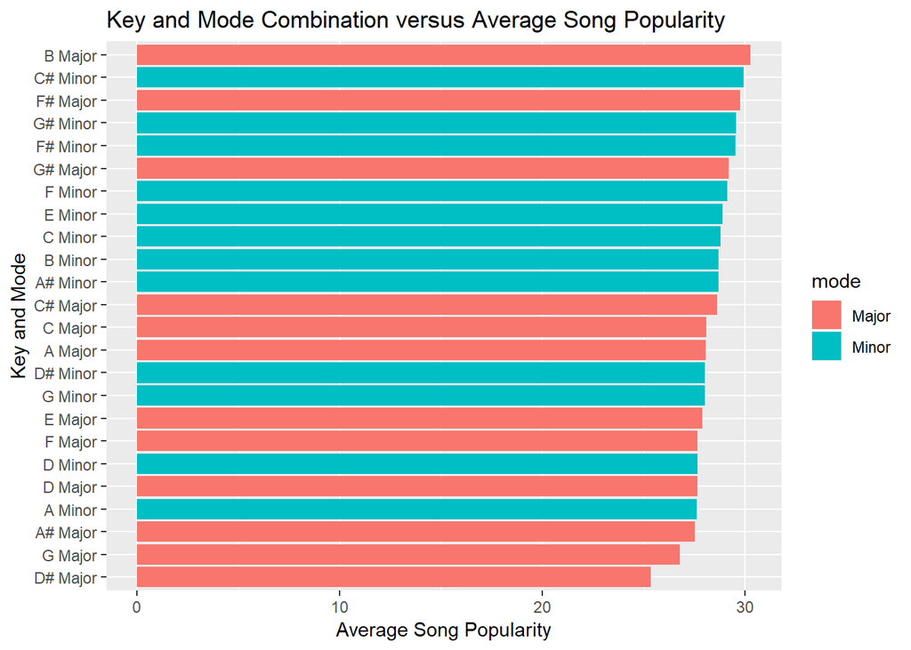

## Tempo vs. Popularity

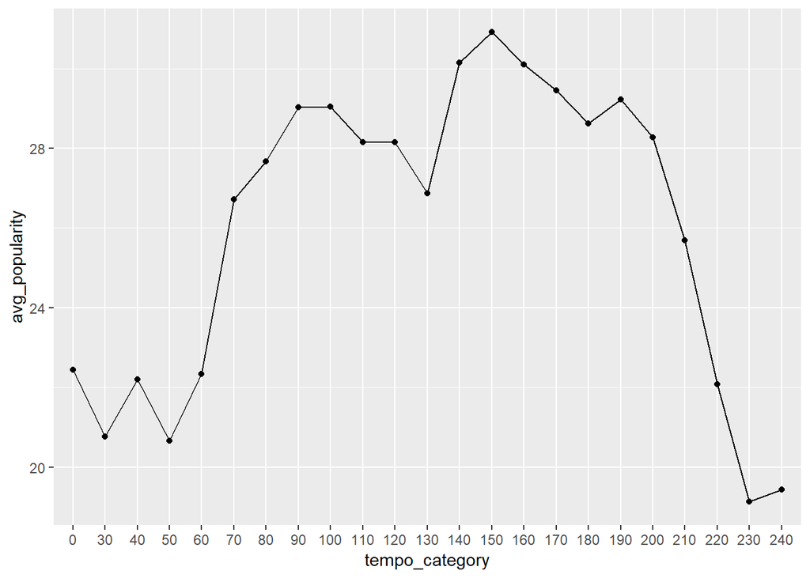

Of all of the numeric independent variables available, we felt that the tempo of a song is probably one of the most influential factors, since it has the ability to control a person’s mood and how they feel in general. Thus, we chose to use a line graph in order to show the general trend of popularity as the tempo goes from low to high.

From the graph’s trend line, it seems that songs of a tempo closer to the middle are the most popular, while people are a little less attracted to songs on the very slow or fast tempo poles of the data. This makes sense, since songs with a slow tempo can come off as boring or just too slow, while songs with a tempo too fast might be too hard to follow or move to.

## Artists vs. Average Popularity

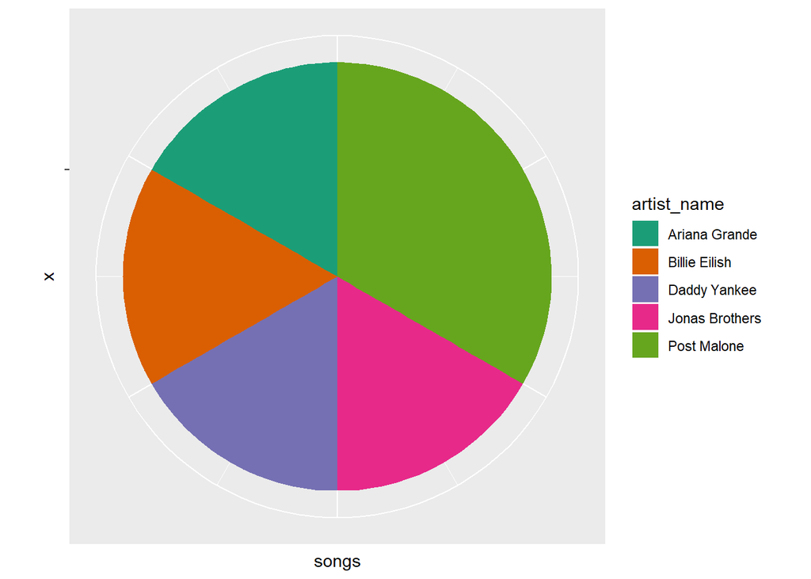

Finally, we were curious about the popularity of artists at the very top of the chart, and which artists with high average popularity have the most songs in their name. To do this, we used a pie chart, since a pie chart would best show the fraction of a total that a certain artist controls. In order to only focus on the artists we were interested in, we filtered the list down to only artists with an average song popularity above 97. Even though it might seem like a huge cut, we felt that it makes sense, since 99% of music streaming is done on 10% of actual available songs, according to some [sources](https://www.digitalmusicnews.com/2018/02/14/spotify-apple-music-top-songs/).